# Q2: Blood Vitamin D, a UPF-Related Nutrient Proxy and Obesity

Plain-language findings, feasibility and next steps

STAT3888 Group 14

# 1 Direct answer

Among **non-pregnant Australians aged 18-64 in the 2011-12 survey**, after accounting for age and sex:

- **Vitamin D:** About 87% higher obesity prevalence in the moderate/severe deficiency group compared with adequate vitamin D. Mild deficiency: no clear difference detected.
- **Dietary proxy:** About 14% higher obesity prevalence for each 10-percentage-point increase in the nutrient proxy.
- **Diabetes comparison:** There is no clear evidence that the vitamin D-obesity association differs by diabetes status. The small diabetes group leaves substantial uncertainty.

**Prevalence means the percentage of people who had obesity when measured. These are associations, not causes or predictions of future obesity.** Our dietary measure is an **unvalidated UPF-related nutrient proxy**, not actual UPF consumption. It adds the energy percentages from saturated/trans fats and added sugars.

# 2 Findings

## 2.1 Blood vitamin D and obesity

Age/sex-adjusted vitamin D comparisons; adequate means at least 50 nmol/L.

| Comparison | Prevalence ratio (95% confidence interval) |
| --- | --- |
| Mild deficiency vs adequate | 1.04 (0.78-1.39) |
| Moderate/severe deficiency vs adequate | 1.87 (1.18-2.98) |

The overall vitamin D test gives **p = 0.0216**. A prevalence ratio of 1 means no difference; a ratio near 2 means approximately twice the prevalence, **not that an individual is “very likely” to be obese**. For illustration, twice a hypothetical 20% is 40%. Moderate and severe deficiency are combined here; severe deficiency alone was not estimated.

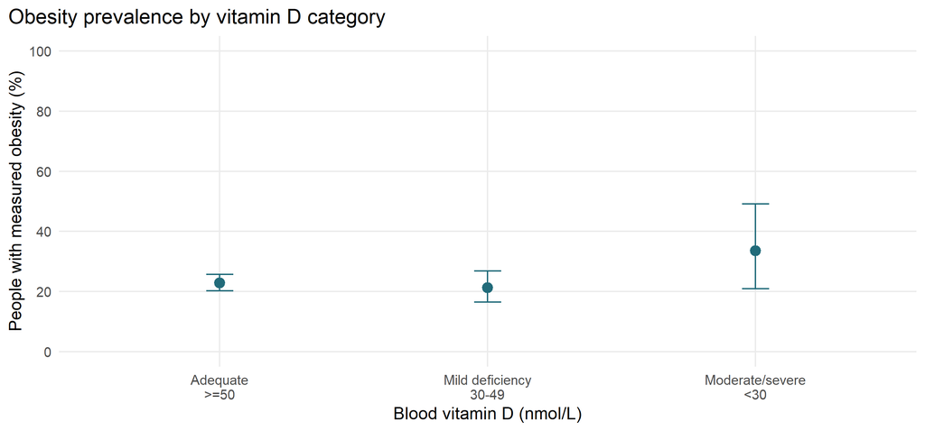

Figure 1. Observed survey-weighted obesity percentages before age/sex adjustment. Bars show 95% confidence intervals. The adjusted results are in the table above.

## 2.2 Nutrient proxy and obesity

Each **10-percentage-point increase** in the proxy was associated with **14% higher relative obesity prevalence** after age/sex adjustment (prevalence ratio **1.14 (95% CI 1.07-1.20)**; p < 0.001).

This is not a 14-percentage-point increase in obesity, and it does not establish an effect of UPF itself. This model is **separate from the vitamin D models**.

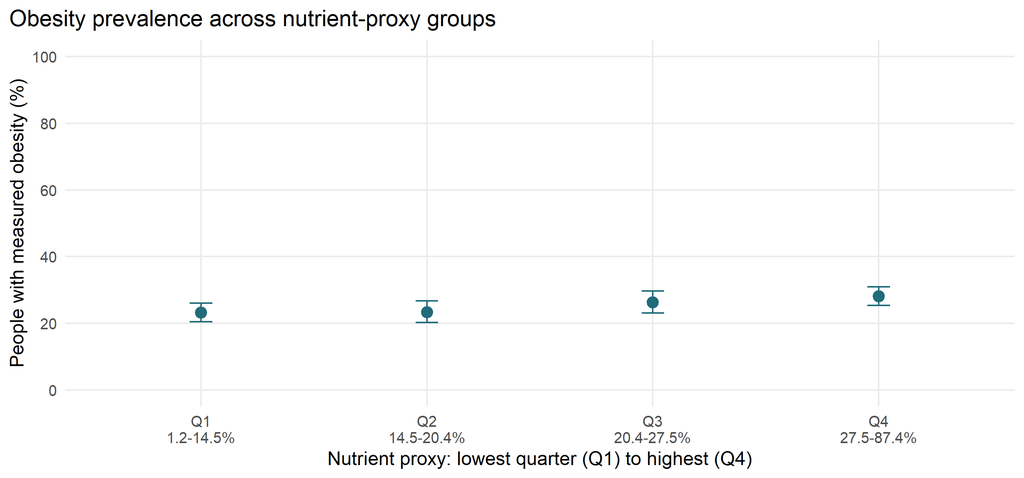

Figure 2. Observed survey-weighted obesity percentages before age/sex adjustment. Quartiles split participants into roughly equal-sized groups. The adjusted model uses the original numeric score.

## 2.3 Does the vitamin D association differ by diabetes?

**We cannot confidently establish a difference between the groups.** The main interaction test gives **p = 0.194**. It adjusts for **age and sex only**, with **no dietary-proxy adjustment**.

For this comparison, deficiency means **<50 versus >=50 nmol/L**. We combine the deficient categories because only 5 participants with diabetes have moderate/severe deficiency.

| Group | Deficient vs adequate: prevalence ratio (95% CI) |
| --- | --- |
| No diabetes | 1.255 (0.998-1.578) |
| Diabetes | 0.717 (0.314-1.638) |

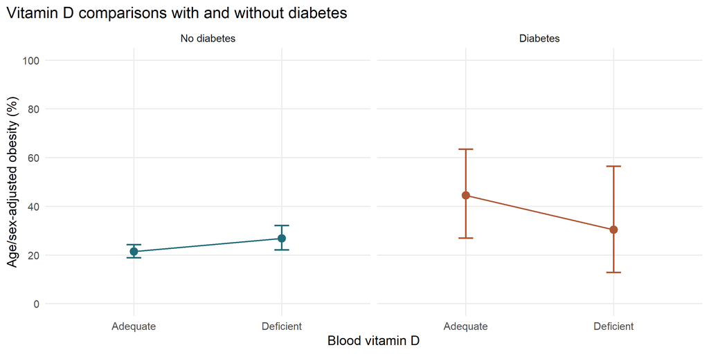

Figure 3. Estimated obesity percentages after giving every group the same age/sex distribution. Bars are 95% confidence intervals. The lines connect estimates; opposite directions alone do not demonstrate an interaction.

In this probability plot, deficiency corresponds to a change of **+5.4 percentage points** without diabetes and **-14.1** with diabetes. The difference between those changes is **-19.5 points** (95% CI **-51.6 to 12.6**; p = **0.229**).

That interval includes zero: the different-looking lines are not sufficient evidence of a real difference. Only **98 participants have diabetes**. A non-significant result does not prove that the associations are identical.

# 3 Data and feasibility

The two source files join one-to-one by person ID. All 12,153 original participants remain in the audit. After age and pregnancy restrictions, 7,215 are eligible; 969 lack usable measured obesity.

| Analysis | Complete participants | Obese | Not obese | Obese: sample % | Obese: weighted % |
| --- | --- | --- | --- | --- | --- |
| Vitamin D | 2,626 | 718 | 1,908 | 27.3 | 23.3 |
| Nutrient proxy | 6,244 | 1,664 | 4,580 | 26.6 | 25.2 |
| Vitamin D by diabetes | 2,617 | 718 | 1,899 | 27.4 | 23.4 |

Each primary analysis uses everyone with the variables **it needs**. There are **2,616 participants with all variables**, used only for the optional diet-adjustment comparison. The sample sizes above overlap; do not add them. Survey weighting accounts for representation, but does not eliminate missing-data bias.

**Pregnancy is handled by restriction:** none of the 117 pregnant participants has usable measured BMI. The findings therefore cannot cover pregnant adults.

# 4 How to interpret this, and what next

**Adjusted** means the model accounts for age and sex differences between groups. **Unadjusted** means it does not, although survey weights are still used. Neither guarantees that all confounding has been removed.

**Confidence intervals** show statistical uncertainty: wider ranges mean less precise estimates.

For the calculations behind every interval and p-value, expand **R code behind confidence intervals and p-values** at the end of this report.

The question is feasible for blood vitamin D, measured obesity and the diabetes comparison. True UPF intake is not measured by our proxy. Other limitations are the small diabetes sample, missing measurements, one-day dietary recall and possible reverse causation.

Next, check whether results depend on the nutrient proxy’s shape or definition, examine missingness and influential survey weights, and agree on additional confounders such as socioeconomic position, physical activity, smoking, season and supplements where available. Do not choose adjustments simply to obtain a small p-value.

**Technical details, cleaning rules and secondary checks**

## Variables and cleaning

| Field | Use and rule |
| --- | --- |
| `BMICATHY` | Measured obesity: codes 7-9 = BMI >=30 kg/m²; 1-6 = not obese; other codes become missing. |
| `VDLCMRGT` | Blood vitamin D categories 1-3 retained; 0/8 become missing. No continuous blood concentration is invented. |
| `SATPER1 + PEADDSD1` | Day-1 saturated/trans-fat plus added-sugar energy percentage. Trans fat is already included; do not add it again. Missing/non-positive energy or invalid percentages produce a missing proxy. No imputat… |
| `DIABPRVE` | HbA1c-based known/new diabetes (1-2) versus no diabetes (3-4, including at-risk). Other codes become missing. Not type-2-specific. |
| `AGEC, SEX, FEMLSBC` | Ages 18-64; age groups 18-24, 25-34, 35-44, 45-54, 55-64; sex. Exclude pregnant women (code 2). Retain men and women with codes 1 or 3-6; exclude unknown pregnancy status. |

The nutrient proxy’s mean is 21.7% and median 20.4% in the dietary sample. 4 zero-energy participants receive a missing proxy. Raw records are unchanged; missing values are not replaced with averages.

| Common inclusion step | Retained n | Excluded at step |
| --- | --- | --- |
| All source participants | 12153 | 0 |
| Aged 18-64 | 7332 | 4821 |
| Known non-pregnant | 7215 | 117 |
| Measured obesity available | 6246 | 969 |

| Variable | Unavailable n | Eligible n | Unavailable % |
| --- | --- | --- | --- |
| Measured obesity | 969 | 7215 | 13.4 |
| Blood vitamin D | 4481 | 7215 | 62.1 |
| Diabetes | 4466 | 7215 | 61.9 |
| Nutrient proxy | 4 | 7215 | 0.1 |
| Positive biomedical weight | 4431 | 7215 | 61.4 |

## Models and initial tests

The primary formulas are:

```r
obese ~ vitamin_d + age_group + sex
obese ~ upf_nutrient_proxy_pct10 + age_group + sex
obese ~ vitamin_d_binary * diabetes + age_group + sex
```

Survey-weighted modified Poisson models estimate prevalence ratios. A logistic model with the **same no-proxy interaction formula** supplies Figure 3’s probabilities, standardised to a common age/sex distribution. Its absolute-difference test and the primary ratio-scale interaction test are different comparisons, so their p-values can differ.

The full survey designs are built before restricting to eligible complete cases. Biomedical models use `NHMSPERW` and `RPWGT01-60`; the dietary model uses `NPAFINWT` and `WPM0101-60`. We use 60 jackknife replicates, multiplier 59/60 and full-sample centring, following the [ABS approach](https://www.abs.gov.au/ausstats/abs%40.nsf/Lookup/4363.0.55.001Technical%2BNote12011-13). Figure 3 refits and reweights each replicate. Its shared age/sex distribution can require extrapolation in sparse diabetic cells.

|  | Test | Participants | p-value |
| --- | --- | --- | --- |
| X-squared…1 | Vitamin D categories: unadjusted | 2626 | 0.1517 |
| X-squared…2 | Proxy quartiles: unadjusted | 6244 | 0.0767 |

| Test | p-value |
| --- | --- |
| Vitamin D: age/sex adjusted | 0.0216 |
| Nutrient proxy: age/sex adjusted | <0.001 |
| Primary diabetes interaction: PR scale | 0.1944 |
| Secondary diabetes interaction: OR scale | 0.2127 |

The initial Rao-Scott tests account for survey design, not age/sex. A quartile test asks whether any group differs; it does not identify which groups differ or establish a trend. These use the new analysis-specific samples and replace the earlier common-sample tests.

## Optional nutrient-proxy adjustment

This is a **secondary check**, not the primary answer. Both models below use exactly the same 2616 people, so the comparison isolates the adjustment choice.

| Model | Group | Deficient vs adequate PR (95% CI) |
| --- | --- | --- |
| Age/sex only | No diabetes | 1.26 (1.00-1.58) |
| Age/sex only | Diabetes | 0.72 (0.31-1.64) |
| Also nutrient proxy | No diabetes | 1.26 (1.00-1.59) |
| Also nutrient proxy | Diabetes | 0.71 (0.31-1.63) |

| Comparison | Interaction p-value |
| --- | --- |
| Same people: age/sex only | 0.194 |
| Same people: also nutrient proxy | 0.191 |

| Model | n | Converged | Fitted values above 1 |
| --- | --- | --- | --- |
| vitamin | 2626 | TRUE | 0 |
| diet | 6244 | TRUE | 0 |
| interaction | 2617 | TRUE | 0 |
| logistic | 2617 | TRUE | 0 |
| same_sample_base | 2616 | TRUE | 0 |
| same_sample_proxy | 2616 | TRUE | 1 |

All models converged with finite coefficients. No primary model produced fitted values above 1. The optional proxy-adjustment check has fitted values above 1 and requires caution. The displayed probabilities use logistic regression. Confidence intervals reflect sampling uncertainty, not dietary-proxy measurement error.

Definitions come from the supplied `AHSnpaBasicCURFdataItemList.xlsx`. The Rmd reads `AHSnpa11bp.csv` and `AHSnpa11bb.csv` and sources the proxy-construction script. It exports current tables, three figures and an all-person inclusion audit. Participant-level data remain Git-ignored.

**R code behind confidence intervals and p-values**

The code below is the **same code executed to produce this report**, displayed again without refitting the models. Run the Rmd from the beginning to create its cleaned data, survey designs and model objects. All intervals are 95%; p-values are two-sided or omnibus tests. No multiple-testing correction is applied, so these remain exploratory results.

| Report result | Calculation below |
| --- | --- |
| Figures 1-2: observed prevalence CIs | Survey-weighted mean, replicate-weight SE, logit-transformed t interval |
| Vitamin D and nutrient-proxy PR CIs; diabetes-group PR CIs | Exponentiated coefficient or linear-contrast t interval |
| Adjusted vitamin D, proxy and interaction p-values | Survey-adjusted Wald F test using `regTermTest()` |
| Initial category/quartile p-values | Rao-Scott survey-adjusted F test using `svychisq()` |
| Figure 3: standardized prevalence CIs | Refit and standardize in each replicate; logit-transformed t interval |
| Figure 3: changes and difference-in-changes CIs/p-values | Replicate-weight covariance; t intervals and two-sided t tests |
| Optional proxy-adjustment sensitivity CIs/p-values | The same ratio-CI and Wald-test functions, on identical participants |

## Survey weights and model fits

For an estimate or vector of estimates, the variance is based on the 60 replicate estimates, centred on the full-sample estimate, with multiplier 59/60. Thus `vcov(model)` below is **survey-adjusted**, not the ordinary independent-observation GLM covariance. Descriptive intervals use `degf(design)`; model intervals/tests use the fitted model’s residual degrees of freedom, not the sample size minus two.

```r
# Full-sample-centred jackknife variance: (59/60) * sum((replicate - full)^2).
make_design <- function(d,weight,reps) {
  d <- d[is.finite(d[[weight]]) & d[[weight]]>0,,drop=FALSE]
  rw <- as.matrix(d[,reps,drop=FALSE])
  stopifnot(length(reps)==60L,all(is.finite(rw)),all(rw>=0))
  svrepdesign(data=as.data.frame(d),weights=reformulate(weight),repweights=rw,
    combined.weights=TRUE,type="other",scale=59/60,rscales=rep(1,60),mse=TRUE)
}

full_biomed <- make_design(all_data,"NHMSPERW",biomed_reps)
vitamin_design <- subset(full_biomed,vitamin_complete)
subgroup_design <- subset(full_biomed,subgroup_complete)
joint_design <- subset(full_biomed,joint_complete)
full_person <- make_design(all_data,"NPAFINWT",person_reps)
diet_design <- subset(full_person,diet_complete)
```

```r
vitamin_formula <- obese~vitamin_d+age_group+sex
diet_formula <- obese~upf_nutrient_proxy_pct10+age_group+sex
interaction_formula <- obese~vitamin_d_binary*diabetes+age_group+sex
vitamin_model <- svyglm(vitamin_formula,design=vitamin_design,family=quasipoisson(link="log"))
diet_model <- svyglm(diet_formula,design=diet_design,family=quasipoisson(link="log"))
interaction_model <- svyglm(interaction_formula,design=subgroup_design,
  family=quasipoisson(link="log"))
logistic_model <- svyglm(interaction_formula,design=subgroup_design,family=quasibinomial())

# Secondary comparison holds participant IDs fixed when adding the proxy.
same_sample_base <- svyglm(interaction_formula,design=joint_design,
  family=quasipoisson(link="log"))
same_sample_proxy <- svyglm(update(interaction_formula,.~.+upf_nutrient_proxy_pct10),
  design=joint_design,family=quasipoisson(link="log"))
```

## Figures 1-2: observed prevalence intervals

For weighted prevalence $p$, the interval is computed on the logit scale using standard error $SE(p)/[p(1-p)]$, then transformed back to percentages. These are not age/sex-adjusted intervals. The same helper also supplies the sample-summary exports.

```r
# Logit-transformed Wald CIs keep prevalence limits between 0 and 1.
prevalence <- function(ds) {
  z <- svymean(~obese,ds)
  p <- unname(coef(z)[1]); se <- unname(SE(z)[1])
  stopifnot(p>0,p<1)
  ci <- plogis(qlogis(p)+c(-1,1)*qt(.975,degf(ds))*se/(p*(1-p)))
  data.frame(n=nrow(ds$variables),obese_n=sum(ds$variables$obese),
    not_obese_n=sum(ds$variables$obese==0),
    sample_pct=100*mean(ds$variables$obese),weighted_pct=100*p,
    low=100*ci[1],high=100*ci[2])
}
by_group <- function(ds,variable) {
  bind_rows(lapply(levels(ds$variables[[variable]]),function(g)
    cbind(group=g,prevalence(ds[ds$variables[[variable]]==g,]))))
}
```

```r
# The points and limits used in Figures 1 and 2:
by_group(vitamin_design, "vitamin_d")
by_group(diet_design, "proxy_quartile")
```

## Adjusted ratios, subgroup intervals and model p-values

`L` selects the coefficient(s) defining a comparison. In the diabetes group, the vitamin D association is the **sum of the vitamin D and interaction coefficients**. Its variance includes their covariance; adding the two standard errors would be incorrect. A ratio CI includes 1 when that comparison is compatible with no association at the 5% level.

```r
# For log-ratio contrast L: eta = L'beta, SE = sqrt(L' V L).
# Exponentiate eta +/- t critical * SE to obtain ratio confidence limits.
linear_estimate <- function(model,L) {
  stopifnot(identical(names(L),names(coef(model))))
  eta <- sum(L*coef(model)); se <- sqrt(as.numeric(t(L)%*%vcov(model)%*%L))
  crit <- qt(.975,model$df.residual)
  c(estimate=exp(eta),low=exp(eta-crit*se),high=exp(eta+crit*se))
}
one_term <- function(model,term,label,model_label) {
  L <- setNames(rep(0,length(coef(model))),names(coef(model)))
  stopifnot(term %in% names(L)); L[term] <- 1
  x <- linear_estimate(model,L)
  data.frame(model=model_label,contrast=label,PR=x[1],low=x[2],high=x[3],row.names=NULL)
}
test_term <- function(model,term,label) {
  z <- regTermTest(model,term)
  data.frame(test=label,F_statistic=as.numeric(z$Ftest),numerator_df=z$df,
    denominator_df=z$ddf,p_value=as.numeric(z$p))
}
subgroup_contrasts <- function(model) {
  bind_rows(lapply(c("No diabetes","Diabetes"),function(g) {
    L <- setNames(rep(0,length(coef(model))),names(coef(model)))
    L["vitamin_d_binaryDeficient"] <- 1
    if(g=="Diabetes") L["vitamin_d_binaryDeficient:diabetesDiabetes"] <- 1
    z <- linear_estimate(model,L)
    data.frame(diabetes=g,ratio=z[1],low=z[2],high=z[3],row.names=NULL)
  }))
}
```

```r
main_results <- bind_rows(
  one_term(vitamin_model,"vitamin_dMild deficiency (30-49)","Mild deficiency vs adequate","Vitamin D"),
  one_term(vitamin_model,"vitamin_dModerate/severe (<30)","Moderate/severe deficiency vs adequate","Vitamin D"),
  one_term(diet_model,"upf_nutrient_proxy_pct10","Nutrient proxy: +10 percentage points","Nutrient proxy"))
main_results$n <- c(nobs(vitamin_model),nobs(vitamin_model),nobs(diet_model))
model_tests <- bind_rows(
  test_term(vitamin_model,~vitamin_d,"Vitamin D: age/sex adjusted"),
  test_term(diet_model,~upf_nutrient_proxy_pct10,"Nutrient proxy: age/sex adjusted"),
  test_term(interaction_model,~vitamin_d_binary:diabetes,"Primary diabetes interaction: PR scale"),
  test_term(logistic_model,~vitamin_d_binary:diabetes,"Secondary diabetes interaction: OR scale"))
subgroup_results <- subgroup_contrasts(interaction_model)
logistic_results <- subgroup_contrasts(logistic_model)
L <- setNames(rep(0,length(coef(interaction_model))),names(coef(interaction_model)))
L["vitamin_d_binaryDeficient:diabetesDiabetes"] <- 1
interaction_ratio <- linear_estimate(interaction_model,L)
```

The vitamin D p-value jointly tests its **two category coefficients**, whereas each vitamin D CI concerns one comparison with adequate levels. The proxy and binary interaction tests each have one numerator degree of freedom. These are Wald tests, not ANOVA of the raw obesity values or likelihood-ratio tests.

| Test | F | Numerator df | Denominator df | p-value |
| --- | --- | --- | --- | --- |
| Vitamin D: age/sex adjusted | 4.1320 | 2 | 52 | 0.0216054 |
| Nutrient proxy: age/sex adjusted | 20.4291 | 1 | 53 | 3.50602e-05 |
| Primary diabetes interaction: PR scale | 1.7291 | 1 | 51 | 0.1944092 |
| Secondary diabetes interaction: OR scale | 1.5929 | 1 | 51 | 0.2126586 |

### Worked example: the primary interaction p-value

Here the null hypothesis is that the deficient-versus-adequate **prevalence ratio is the same in both diabetes groups**. For this single coefficient, the Wald F statistic equals the squared t statistic. The code also obtains the ratio of those prevalence ratios and its CI directly from the fitted model; no reported values are hard-coded.

```r
term <- "vitamin_d_binaryDeficient:diabetesDiabetes"
beta <- unname(coef(interaction_model)[term])
se <- sqrt(vcov(interaction_model)[term, term])
df <- interaction_model$df.residual
t_stat <- beta / se
F_stat <- t_stat^2
p <- pf(F_stat, df1=1, df2=df, lower.tail=FALSE)
ratio <- exp(beta)
ci <- exp(beta + c(-1, 1) * qt(.975, df) * se)

interaction_calculation <- data.frame(
  beta=beta, SE=se, t=t_stat, F=F_stat, df1=1, df2=df, p_value=p,
  ratio_of_PRs=ratio, CI_low=ci[1], CI_high=ci[2])
stopifnot(isTRUE(all.equal(p, model_tests$p_value[3], tolerance=1e-10)),
          isTRUE(all.equal(unname(c(ratio, ci)),
                           unname(interaction_ratio), tolerance=1e-10)))
knitr::kable(data.frame(Statistic=names(interaction_calculation),
  Value=as.numeric(interaction_calculation[1, ])), digits=6)
```

| Statistic | Value |
| --- | --- |
| beta | -0.559870 |
| SE | 0.425774 |
| t | -1.314949 |
| F | 1.729091 |
| df1 | 1.000000 |
| df2 | 51.000000 |
| p_value | 0.194409 |
| ratio_of_PRs | 0.571283 |
| CI_low | 0.243012 |
| CI_high | 1.343000 |

The interaction estimate is 1.31 standard errors from zero. The ratio of prevalence ratios is 0.571 (95% CI 0.243 to 1.343). Its interval includes 1, consistent with p = 0.194409.

## Initial unadjusted category tests

These test independence between obesity and the vitamin D categories or proxy quartiles, allowing for survey design but not adjusting for age/sex. `svychisq(..., statistic="F")` supplies the Rao-Scott F approximation and its design-adjusted degrees of freedom; do not substitute an ordinary `chisq.test()`.

```r
initial_test <- function(ds,variable,label) {
  z <- svychisq(reformulate(c(variable,"obesity_status")),ds,statistic="F")
  data.frame(test=label,n=nrow(ds$variables),F_statistic=unname(z$statistic),
    numerator_df=unname(z$parameter[1]),denominator_df=unname(z$parameter[2]),p_value=z$p.value)
}
initial_tests <- bind_rows(
  initial_test(vitamin_design,"vitamin_d","Vitamin D categories: unadjusted"),
  initial_test(diet_design,"proxy_quartile","Proxy quartiles: unadjusted"))
```

|  | Test | n | F | Numerator df | Denominator df | p-value |
| --- | --- | --- | --- | --- | --- | --- |
| X-squared…1 | Vitamin D categories: unadjusted | 2626 | 1.9533 | 1.7822 | 105.1491 | 0.1516745 |
| X-squared…2 | Proxy quartiles: unadjusted | 6244 | 2.3480 | 2.8902 | 170.5221 | 0.0767428 |

## Figure 3: standardized probabilities and absolute contrasts

Each replicate refits the logistic model and averages each scenario’s predictions over the **same age/sex reference population**, using that replicate’s weights. Scenario order is adequate/no diabetes, deficient/no diabetes, adequate/diabetes, deficient/diabetes. `withReplicates()` estimates the joint covariance of the four logit probabilities and the absolute contrasts. This preserves dependence between predictions instead of treating the plotted points as independent.

The four probability CIs are constructed on the logit scale. Absolute changes use $\widehat{\Delta}\pm t_{0.975,df}SE(\widehat{\Delta})$; their p-values are `2 * pt(abs(estimate / SE), df, lower.tail=FALSE)`. These tests concern **percentage-point differences**, not the primary prevalence-ratio interaction.

```r
# Standardise all four scenarios to a common weighted AGE/SEX distribution.
# Each replicate refits the model and reweights the reference population.
scenarios <- expand.grid(vitamin_d_binary=c("Adequate","Deficient"),
  diabetes=c("No diabetes","Diabetes"),stringsAsFactors=FALSE)
standardise <- function(w,data) {
  w <- as.numeric(w); data$.w <- w/mean(w)
  fit <- glm(interaction_formula,data=data,weights=.w,family=quasibinomial())
  stopifnot(fit$converged,all(is.finite(coef(fit))))
  p <- vapply(seq_len(nrow(scenarios)),function(i) {
    nd <- data
    nd$vitamin_d_binary <- factor(scenarios$vitamin_d_binary[i],levels(data$vitamin_d_binary))
    nd$diabetes <- factor(scenarios$diabetes[i],levels(data$diabetes))
    weighted.mean(predict(fit,newdata=nd,type="response"),w)
  },numeric(1))
  c(setNames(qlogis(p),paste0("scenario",1:4)),
    PD_no=100*(p[2]-p[1]),PD_yes=100*(p[4]-p[3]),
    difference_PD=100*((p[4]-p[3])-(p[2]-p[1])))
}
std <- withReplicates(subgroup_design,standardise,return.replicates=TRUE)
theta <- coef(std); theta_se <- sqrt(diag(vcov(std)))
crit <- qt(.975,logistic_model$df.residual)
std_prevalence <- scenarios %>% mutate(
  vitamin_d_binary=factor(vitamin_d_binary,c("Adequate","Deficient")),
  diabetes=factor(diabetes,c("No diabetes","Diabetes")))
std_prevalence$prevalence <- 100*plogis(theta[1:4])
std_prevalence$low <- 100*plogis(theta[1:4]-crit*theta_se[1:4])
std_prevalence$high <- 100*plogis(theta[1:4]+crit*theta_se[1:4])
std_difference <- data.frame(contrast=c("Deficient - adequate: no diabetes",
  "Deficient - adequate: diabetes","Difference in differences: diabetes - no diabetes"),
  percentage_points=unname(theta[5:7]),low=unname(theta[5:7]-crit*theta_se[5:7]),
  high=unname(theta[5:7]+crit*theta_se[5:7]),
  p_value=unname(2*pt(abs(theta[5:7]/theta_se[5:7]),df=logistic_model$df.residual,lower.tail=FALSE)))
```

| Contrast | Percentage points | CI low | CI high | p-value |
| --- | --- | --- | --- | --- |
| Deficient - adequate: no diabetes | 5.365731 | -0.318194 | 11.04966 | 0.063741 |
| Deficient - adequate: diabetes | -14.118441 | -45.700751 | 17.46387 | 0.373689 |
| Difference in differences: diabetes - no diabetes | -19.484172 | -51.590528 | 12.62218 | 0.228705 |

## Optional proxy-adjustment sensitivity

The two fits were specified under **Survey weights and model fits** above. These calls reuse the same contrast and Wald-test helpers on the same complete-case sample; they do not change the primary analysis.

```r
sensitivity <- bind_rows(
  subgroup_contrasts(same_sample_base) %>% mutate(model="Age/sex only"),
  subgroup_contrasts(same_sample_proxy) %>% mutate(model="Also nutrient proxy"))
sensitivity$n <- nobs(same_sample_base)
sensitivity_tests <- bind_rows(
  test_term(same_sample_base,~vitamin_d_binary:diabetes,"Same people: age/sex only"),
  test_term(same_sample_proxy,~vitamin_d_binary:diabetes,"Same people: also nutrient proxy"))
```